# Sesion 13a - Laboratorio

Juan Carlos Martinez-Ovando

Departamento Academico de Actuaria

Primavera 2019

# 1 Modelo de agregada de riesgo

Consideremos los datos de `AllState` nuevamente:

```r
data <- read.csv("./d4a_allstateclaim_data.csv")
head(data)
```

```
##   Household_ID Vehicle Calendar_Year Model_Year Blind_Make Claim_Amount
## 1            1       3          2005       2005          K            0
## 2            2       2          2005       2003          Q            0
## 3            3       1          2005       1998         AR            0
## 4            3       1          2006       1998         AR            0
## 5            3       2          2005       2001          D            0
## 6            3       2          2006       2001          D            0
```

*En este caso el archivo de datos esta contenido en la carpeta `Notebook` del repositorio del curso.* Recordemos de estos datos el contenido:

## 1.1 Descripcion

Los datos corresponden a reclamos por polizas de un seguro de autos de la empresa *AllState*. Se supone que cada poliza es contratada por un hogar. Los montos de reclamos para las diferentes polizas pueden diferenciarse por anio de suscripcion, modelo del vehiculo y fabricante.

## 1.2 Diccionario

- `Household_ID` INT - Identificador numerico de la poliza (una por hogar).
- `Vehicle` INT - identificador del vehiculo asegurado por poliza (dentro de cada hogar).
- `Calendar_Year` INT - Anio calendario en el que el vehiculo fue asegurado.
- `Model_Year` INT - Anio calendario de fabricacion/venta del vehiculo.
- `Blind_Make` INT - Fabricante del vehiculo (discresional).
- `Claim_Amount` INT - Monto de reclamo asociado con el vehiculo (montos en USD).

**Nota:** Las polizas con reclamos nulos (`Claim_Amount`==0) corresponden a casos no siniestrados.

# 2 Modelo

## 2.1 Pregunta clave

?`Como identificar el tipo de enfoque de modelacion? a.k.a.:

- Enfoque de riesgo individual
- Enfoque de riesgo colectivo

## 2.2 Frecuencia de Siniestros

Empiricamente, podemos identificar el enfoque con base en el `contenido de la informacion/datos` proporcionada. En este caso:

- En este caso, el campo `Claim_Amount`, que indica el monto del reclamo de siniestro, esta asociado univocamente a cada poliza, i.e. `Household_ID` para cada **periodo de operacion** (`Calendar_Year`).

Asi, podemos definir:
$$\iota_{tj} =
\begin{cases}
1, & \text{ poliza }j, \text{ siniestrada en }t\\
0, & \text{ e.o.c. },
\end{cases}$$
para $t=2005,2006,2007$ y $j=1,\ldots,J_t$.

```r
data <- as.data.frame(data)
data[,"iota"] <- 0
data[which(data$Claim_Amount>0),"iota"] <- 1
table(data[,c("Calendar_Year","iota")])
```

```
##              iota
## Calendar_Year      0      1
##          2005 327064   3001
##          2006 347242   2749
##          2007 365839   2680
```

De esta forma, tenemos que la suscripcion $J_t$ para los tres anios, es:

```r
table(data$Calendar_Year)
```

```
##
##   2005   2006   2007
## 330065 349991 368519
```

De igual forma, el numero de siniestros en esos anios, $N_t$, definido como
$$N_t=\sum_{j=1}^{J_t}\iota_{tj},$$
tiene los siguientes datos realizados:

```r
table(data[which(data$iota==1),"Calendar_Year"])
```

```
##
## 2005 2006 2007
## 3001 2749 2680
```

Como mencionamod, dado que cada poliza puede tener a lo mas un siniestro en cada periodo de operacion (en este caso), el modelo pertinente para $N_t$ podra ser
$$N_t \sim \text{Bin}(n|J_t,\theta_t),$$
reconocidiendo que cada `periodo de operacion` puede tener una incidencia en siniestralidad distinta.

```r
theta_est <- as.matrix(table(data[which(data$iota==1),"Calendar_Year"])) / as.matrix(table(data$Calendar_Year))
theta_est <- as.data.frame(theta_est)
colnames(theta_est) <- c("Theta_ML")
theta_est <- ts(theta_est,start = c(2005), frequency = 1)
theta_est
```

```
## Time Series:
## Start = 2005
## End = 2007
## Frequency = 1
##         Theta_ML
## [1,] 0.009092149
## [2,] 0.007854488
## [3,] 0.007272352
```

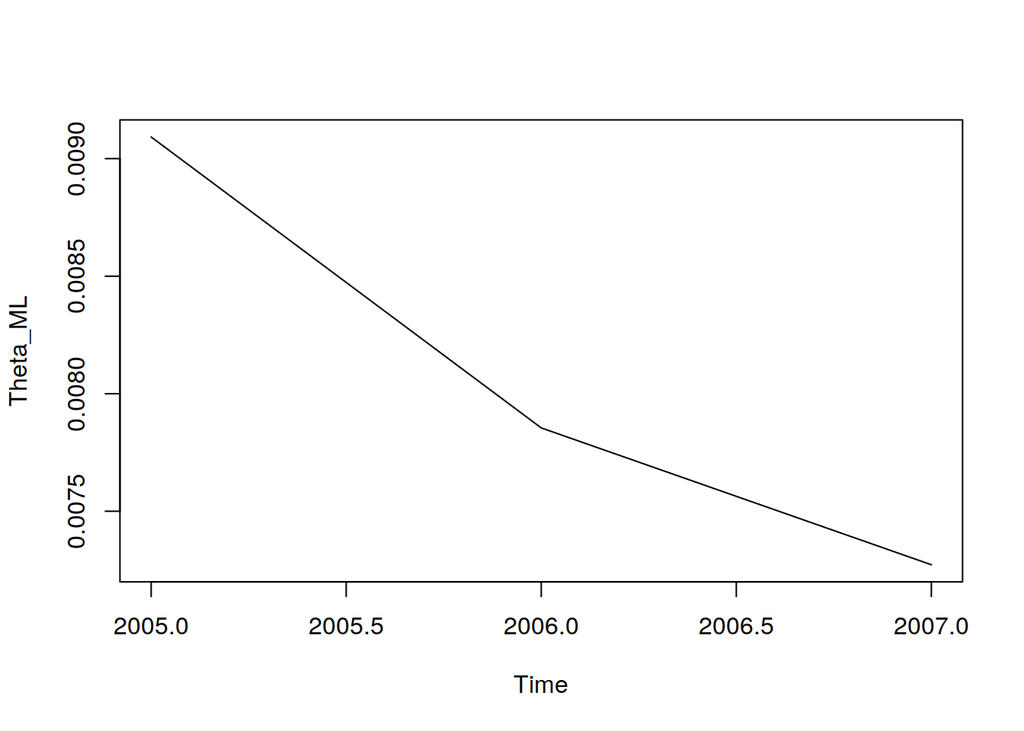

```r
plot(theta_est)
```

## 2.3 Severidades

Ahora bien, respecto a la severidad individual, consideramos la variable $X_{tj}$ condicional en $\iota_{tj}=1$, i.e. consideramos los datos con `Claim_Amount>0`.

Esto nos brindara la oportunidad de obtener informacion respecto al **monto agregado de siniestros**, $S_t$, definido como
$$\begin{eqnarray}
S_{t} & = & \sum_{j=1}^{J_t} X_{tj}\iota_{tj} \nonumber \\
& = & \sum_{i=1}^{N_t} X_{ti}\mathbb{I}(X_{ti}>0), \nonumber
\end{eqnarray}$$
donde

- $J_t$ representa el tamanio de la suscripcion, y
- $N_t$ representa la frecencia de siniestros,

ambas cantidades en $t$.

**NOTA:** Recordemos que aunque $N_t$ la podemos medir en terminos absolutos, en realidad su informacion es referida a $J_t$ (esto directamente en el caso de **enfoque de riesgo individual**).

En este caso, los montos agregados de siniestros *anio-con-anio*, son:

```r
data_x <- data[which(data$iota==1),"Claim_Amount"]
data_t <- data[which(data$iota==1),"Calendar_Year"]
(S_t <- rowsum(data_x, data_t))
```

```
##          [,1]
## 2005 521181.0
## 2006 499706.8
## 2007 423182.4
```

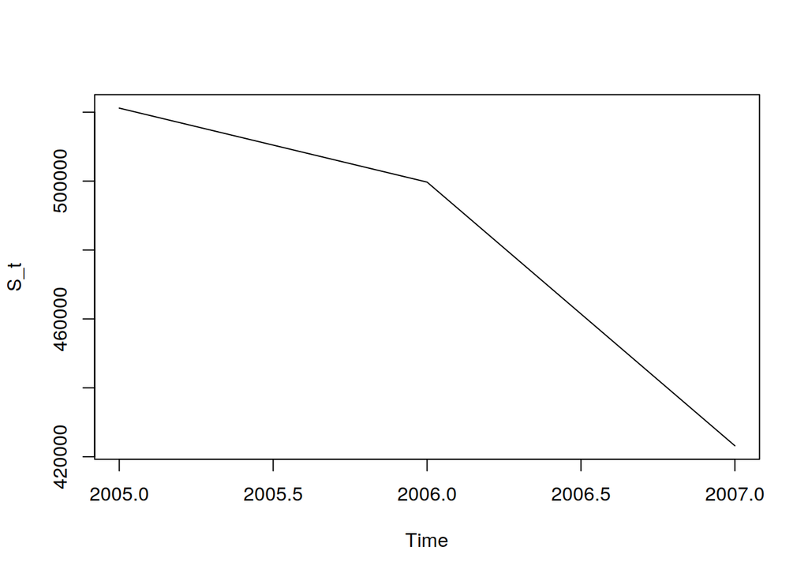

```r
S_t <- ts(S_t,start = c(2005), frequency = 1)
plot(S_t)
```

Pero, **recordemos** que la informacion en $S_t$ en realidad proviene de la informacion de las $(x_{ti})_{i=1}^{n_t}$ correspondientes.

La informacion desagregada de las $(x_{ti})_{i=1}^{n_t}$, *periodo-a-periodo* puede verse de la siguiente forma:

### 2.3.1 Para 2005

```r
data_x1 <- data[which(data$iota==1 & data$Calendar_Year==2005),"Claim_Amount"]
summary(data_x1)
```

```
##     Min.  1st Qu.   Median     Mean  3rd Qu.     Max.
##    0.049   10.139   35.947  173.669  132.776 6422.466
```

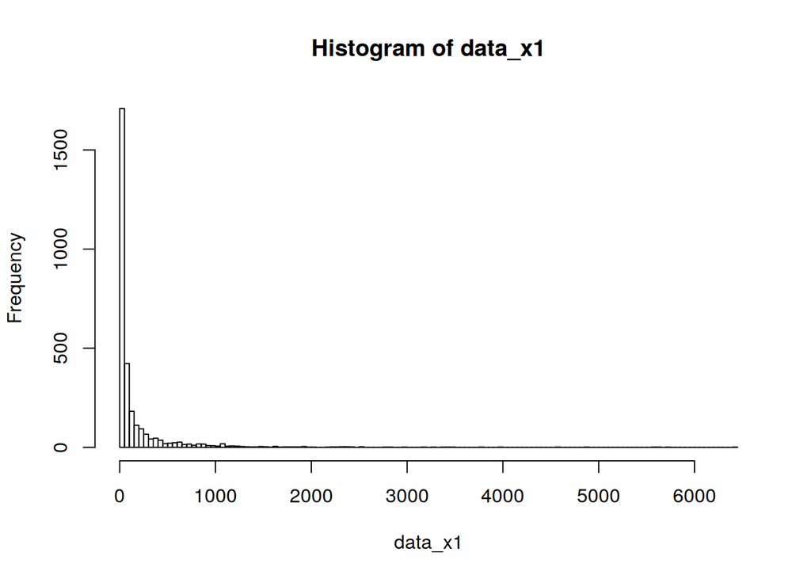

```r
hist(data_x1,100)
```

### 2.3.2 Para 2006

```r
data_x2 <- data[which(data$iota==1 & data$Calendar_Year==2006),"Claim_Amount"]
summary(data_x2)
```

```
##     Min.  1st Qu.   Median     Mean  3rd Qu.     Max.
##    0.003    9.876   35.895  181.778  141.500 4902.777
```

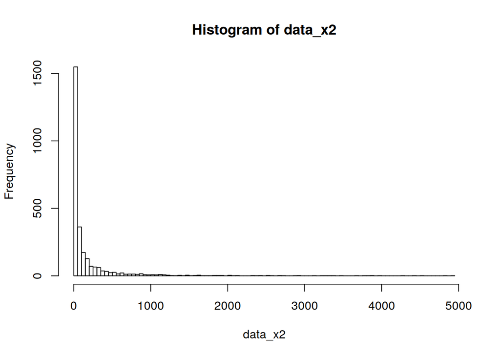

```r
hist(data_x2,100)
```

### 2.3.3 Para 2007

```r
data_x3 <- data[which(data$iota==1 & data$Calendar_Year==2007),"Claim_Amount"]
summary(data_x3)
```

```
##     Min.  1st Qu.   Median     Mean  3rd Qu.     Max.
##    0.023   10.484   39.552  157.904  145.546 3679.300
```

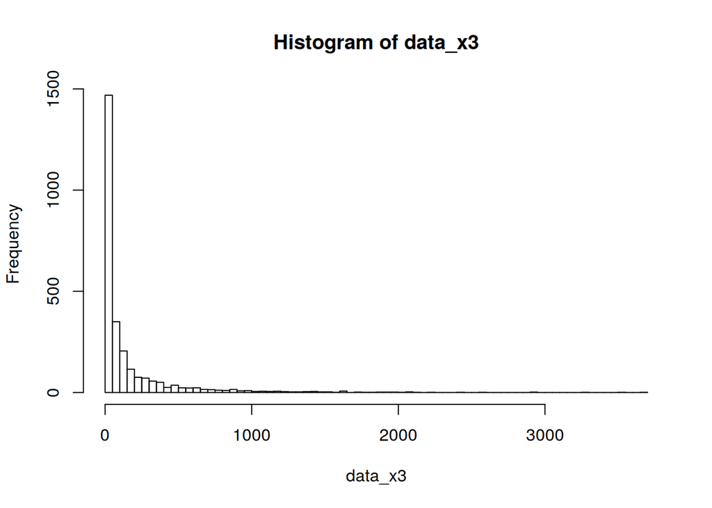

```r
hist(data_x3,100)
```

### 2.3.4 Observaciones

De los datos, podemos observar los **siguientes hechos estilizados**

- *Anio-con-anio*, el **tercer cuantil muestral** muestra una ligera tendencia a la alza, pero en niveles semejantes (i.e. montos en el orden de $140$ unidades).
- Sin embargo, *anio-con-anio*, el valor maximo (i.e. rango entre el `maximo muestral` y el `tercer cuantil muestral`) muestra una dentencia a la baja.
- El `monto mediano individual muestral` es en $2005$ y $2006$ semejante, mientras que en $2007$ los datos muestran un repunte en aproximadamente $4$ unidades.
- En todos los anios, el `primer cuantil muestral` es semejante en nivel.

```r
data_x <- data[which(data$iota==1),c("Calendar_Year","Claim_Amount")]
data_x$Calendar_Year <- as.factor(data_x$Calendar_Year)
colnames(data_x)
```

```
## [1] "Calendar_Year" "Claim_Amount"
```

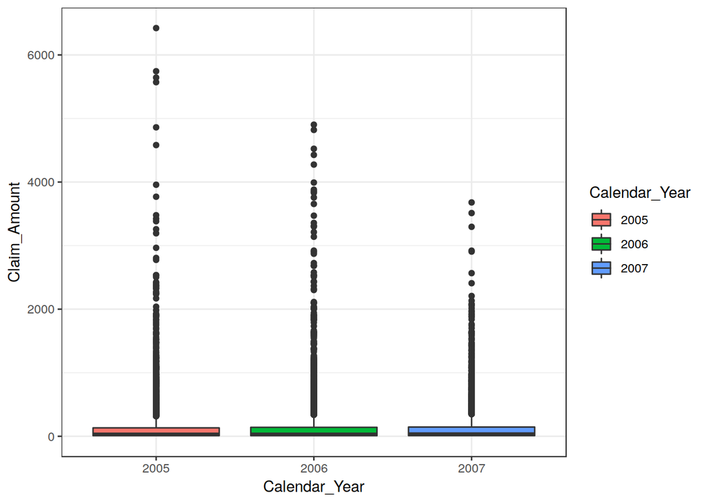

```r
if(!require('ggplot2')){install.packages("ggplot2")}
library("ggplot2")
ggplot(data = data_x, aes(x = Calendar_Year, y = Claim_Amount)) +
  geom_boxplot(aes(fill = Calendar_Year), width = 0.8) + theme_bw()
```

# 3 Modelacion

Empezaremos modelando los datos, *periodo-a-periodo*,
$$\{n_t,(x_{ti})_{i=1}^{n_t}\},$$
sujeto a $J_t$, para $t=2005,2006,2007$, sujeto a $J_y$ de la manera mas simple:

- **Homogeneidad** en $t$, i.e.

$$\begin{eqnarray}
N_t & \sim & \text{Bin}(n|J_t,\theta), \nonumber \\
x_{ti} & \sim & \text{Exp}(x|\lambda), \nonumber
\end{eqnarray}$$
con $0<\theta<1$ y $\lambda>0$ parametros desconocidos.

- **Simetria estocastica** en $t$ e $i=1,\ldots,n_t$, expresada en la forma de `independencia estocastica` entre `periodos` y `entre polizas`.

## 3.1 Observaciones

- Los parametros $\theta$ y $\lambda$ son los mismos para todo $t$ (este es un supuesto no sustentable, dados los comentarios anteriores).
- El supuesto de `independencia estocastica` no es necesariamente sustentable, al menos respecto a $t$.
- El supuesto distribucional para las $X_{tj}$ tampoco es necesariamente sustentable, porque las caracteristicas de cambio en las $x_{tj}$ a traves del tiempo $t$ indica que la distribucion subyacente para $x_{tj}$ es recomendable tenga tres parametros (**mas adelante regresaremos a esto**).

## 3.2 Parametros

Con base en los datos,
$$\{n_t,(x_{ti})_{i=1}^{n_t}\},$$
buscaremos encontrar los parametros
$$(\theta,\lambda) \in (0,1)\times (0,\infty),$$
mas adecuados.

La forma de encontrarlos es a traves de la funcion de verosimilitud,

## 3.3 Verosimilitud

De esta forma, la verosimilitud para $(\theta,\lambda)$ dados los `datos` queda expresada como,
$$\begin{eqnarray}
lik(\theta,\lambda|\text{datos}) & = & p(n_{2005},(x_{2005,i})_{i=1}^{n_{2005}},n_{2006},(x_{2006,i})_{i=1}^{n_{2006}},n_{2007},(x_{2007,i})_{i=1}^{n_{2007}}|\theta,\lambda) \nonumber \\
& = & \prod_{t=2005}^{2007}p(n_{t},(x_{t,i})_{i=1}^{n_{t}}|\theta,\lambda)\nonumber \\
& = & \prod_{t=2005}^{2007}\text{Bin}(n_{t}|J_t,\theta) \times \prod_{t=2005}^{2007}\prod_{i=1}^{n_t}\text{Exp}(x_{t,i}|\lambda)\nonumber \\
& = & lik\left(\theta|(J_t,n_t)_{t=2005}^{2007}\right) \times lik\left(\lambda|(x_{t,i})_{t=2005,i=1}^{2007,n_t}\right).\nonumber
\end{eqnarray}$$

Noten que en la expresion anterior se manifiesta el **supuesto de separabilidad** que comentamos en clase previamente.

```r
theta_grid <- seq(0,1,0.01)
lambda_grid <- seq(0,1000,1)
if(!require('lattice')){install.packages("lattice")}
library("lattice")
data_n <- sum(data$iota)
data_J <- nrow(data)
data_xsum <- sum(data[which(data$iota==1),"Claim_Amount"])
theta <- data_n/data_J; lambda <- (data_xsum / data_n)
loglikelihood <- function(theta,lambda,data_n,data_J,data_xsum){
  loglik.theta <- data_n*log(theta) + (data_J-data_n)*log(1-theta)
  loglik.lambda <- data_n*log(lambda) -lambda*data_xsum
  loglik <- loglik.theta + loglik.lambda
  return(loglik)
}
loglikelihood(theta,lambda,data_n,data_J,data_xsum)
```

```
## [1] -247376851
```

```r
thetalambda_grid <- expand.grid( x = theta_grid, y = lambda_grid)
dim(thetalambda_grid)
```

```
## [1] 101101      2
```

```r
loglik_grid <- matrix(NaN,ncol=1,nrow=nrow(thetalambda_grid))
G <- nrow(thetalambda_grid)
g <- 1
for(g in 1:G){loglik_grid[g] <- loglikelihood(thetalambda_grid[g,1],thetalambda_grid[g,2],data_n,data_J,data_xsum)}
```

```
if(!require('plot3D')){install.packages("plot3D")}
library("plot3D")

scatter3D(thetalambda_grid[,1], thetalambda_grid[,2], loglik_grid,
          pch = 18, cex = 2,
          theta = 20, phi = 20, ticktype = "detailed",
          xlab = "theta", ylab = "lambda", zlab = "log-lik",
          surf = list(x = thetalambda_grid[,1], y = thetalambda_grid[,2], z = loglik_grid,
                      facets = NA, fit = fitpoints), main = "")
```

## 3.4 Estimacion

De esta forma, el **modelo especifico** mas compatible con los datos (a.k.a. el que maximiza la verosimilitud) es
$$p\left(N_t,(X_{ti})_{i=1}^{N_t}\right)=\text{Bin}(n|J_t,\theta^{*}) \prod_{i=1}^{n}\text{Exp}(x|\lambda^{*}),$$
con
$$\begin{eqnarray}
\theta^{*} & = &\arg\max_{\theta\in (0,1)}lik\left(\theta|(J_t,n_t)_{t=2005}^{2007}\right) \nonumber \\
\lambda^{*} & = &\arg\max_{\lambda\in (0,\infty)}lik\left(\lambda|(x_{t,i})_{t=2005,i=1}^{2007,n_t}\right) \nonumber.
\end{eqnarray}$$

Es decir, en nuestro modelo tenemos que los estimadores puntuales $\theta^{*}$ y $\Lambda^{*}$ son:

```r
theta_star <- data_n/data_J
lambda_star <- (data_xsum / data_n)^(-1)
theta_star; lambda_star
```

```
## [1] 0.008039482
```

```
## [1] 0.005837666
```

Es decir, las masas de probabilidades/densidades de estos componentes son

**Masas de probabilidades**

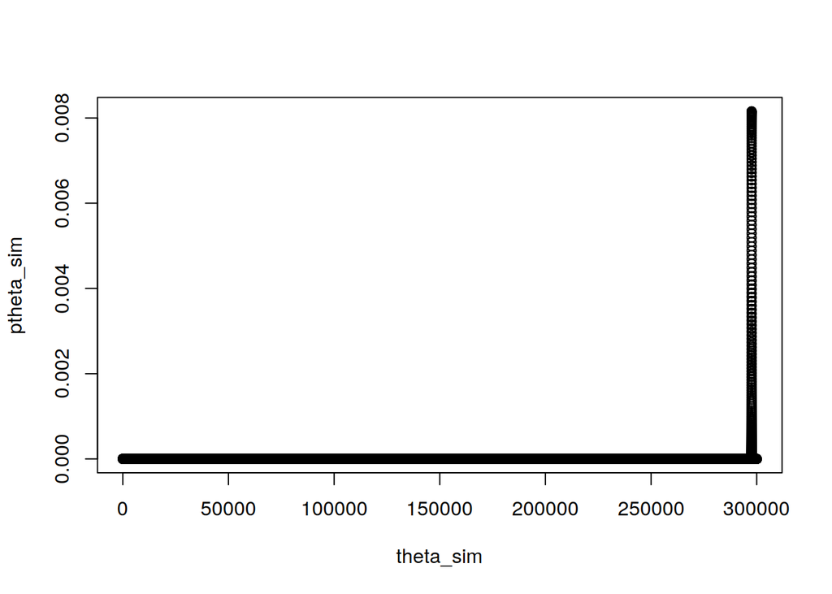

```r
J <- 300000
theta_sim <- seq(0,J,by = 1)
ptheta_sim <- dbinom(theta_sim,J,1-theta_star)
plot(theta_sim,ptheta_sim)
```

**Densidad**

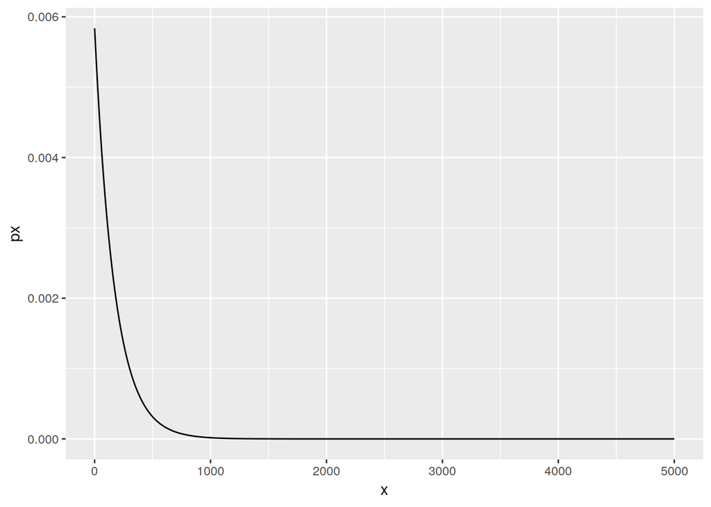

```r
lambda_sim <- seq(0, 5000, length.out=1000)
lambda_frame <- data.frame(x=lambda_sim, px=dexp(lambda_sim, rate=lambda_star))
if(!require('ggplot2')){install.packages("ggplots")}
library("ggplot2")
ggplot(lambda_frame, aes(x=x, y=px)) + geom_line()
```

- La variablidad que estas dos mediciones de probabilidad describen se conocecomo **variablidad o incertidumbre aleatoria**. Esto es porque hacen referencia a la realizacion de $N$ y de las $X_i$, solamente, considerando un modelo especifico dado –en este caso $\text{Bin}(n|J,\theta)$ y $\text{Exp}(x|\lambda)$–.

**Estos parametros resumen la informacion contenida en el conjunto de datos de tres anio de operacion: `2005`, `2006` y `2007`.**

# 4 Agregacion de riesgos `2008` - Enfoque 1

$$P(X_{2008,j})=\theta^*\delta_{\{0\}}(x)+(1-\theta^*)\text{Exp(x|\lambda^{*})},$$
para $j=1,\ldots,J_{2008}$.